# Training NFL Spread Pool Models for the 2025 Season

David Cohn

2025-09-16

My aim is to develop one or more regression models using the caret package that predict the point margin of NFL games based on a) their final point spread (as of Sunday morning, for most games), and b) the difference in DAVE between the two teams. See the README for more information on the rationale and methodology.

The dataset that I have available for developing these models contains (almost) every game from the 2020, 2021, 2022, 2023, and 2024 NFL regular seasons. I used spreadsheets to record information about each game before making my picks in those years, including the final betting line and the difference in DAVE. I did switch to using Weighted DVOA in each season once that metric became available - usually around the midpoint of the season.

I’ll use the read_sheet() function from the googlesheets4 package to load the data from those Google sheets into R.

```r
read_nfl_predictor_sheet <- function(sheet_id) {
  sheet_data <- read_sheet(sheet_id) %>%
    select(
      `Week`, `OFP Line`, `Final Betting Line`, `DAVE Difference`, `Outcome`
    ) %>%
    filter(if_all(everything(), ~ !is.na(.x)))

  return(sheet_data)
}

game_data <- map(sheet_ids, read_nfl_predictor_sheet) %>%
  bind_rows()

game_data %>%
  slice_head(n = 5) %>%
  kbl(
    align = rep("c", ncol(game_data)),
    caption = 'Initial rows of the "game_data" table',
    digits = 2,
    col.names = c(
      "Week", "Pool Spread", "Final Spread", "DAVE Difference", "Actual Margin"
    )
  ) %>%
  kable_styling(
    bootstrap_options = c("striped", "hover", "condensed", "responsive")
  )
```

Initial rows of the “game_data” table

| Week | Pool Spread | Final Spread | DAVE Difference | Actual Margin |
| --- | --- | --- | --- | --- |
| 1 | 2.5 | 2.75 | -0.03 | 7 |
| 1 | 2.5 | 1.50 | -0.07 | 5 |
| 1 | 4.5 | 3.50 | 0.16 | 37 |
| 1 | 4.5 | 4.00 | -0.04 | 7 |
| 1 | -2.5 | -3.00 | -0.24 | -2 |

I’ll split this dataset 80/20 into training and test datasets. Because I used slightly different metrics at different points in the season, and because I expect the home-field advantage to vary over the course of the season, I’ll ensure that the two datasets contain similar proportions of games from each week.

```r
set.seed(508) # Brett Favre - career TD passes

features <- select(game_data, `Final Betting Line`, `DAVE Difference`) %>%
  as.data.frame()
responses <- as.data.frame(game_data$Outcome)

train_indices <- createDataPartition(game_data$Week, p = 0.8, list = FALSE)
train_features <- features[train_indices, ]
train_responses <- responses[train_indices]
test_features <- features[-train_indices, ]
test_responses <- responses[-train_indices]
```

Because points are scored in discrete chunks in football (typically 3 and 7), I don’t anticipate the expected point margin in a game to be proportional to the difference in quality between the two teams. Thus I’ll try training a non-linear model first, namely a random forest regression model.

I’ll tune the following hyperparameters using out-of-bag error estimates (repeated cross-validation was used prior to 2025):

- mtry: the number of randomly chosen features that each node can choose from to split observations
- min.node.size: the minimum number of observations that a node must contain for it to be split
- splitrule: the method that each node uses to determine which breakpoint to use when splitting

```r
get_rf_cv_results <- function(n_trees, grid) {
  rf_fit <- train(
    x = train_features,
    y = train_responses,
    method = "ranger",
    trControl = trainControl(method = "oob"),
    tuneGrid = grid,
    num.trees = n_trees
  )

  rf_fit_results <- rf_fit$results %>%
    mutate(num.trees = n_trees) %>%
    select(num.trees, mtry, min.node.size, splitrule, RMSE)

  return(rf_fit_results)
}
```

And now I can define a hyperparameter grid and proceed with the tuning.

```r
rf_tuning_grid <- expand.grid(
  mtry = 1:2,
  min.node.size = seq(from = 1, by = 2, to = 15),
  splitrule = c("variance", "extratrees", "maxstat")
)

rf_hyperparam_opt_results <-
  get_rf_cv_results(n_trees = 100, grid = rf_tuning_grid)

slice_min(rf_hyperparam_opt_results, order_by = RMSE, n = 10) %>%
  kbl(
    align = rep("c", ncol(rf_hyperparam_opt_results)),
    caption = 'Random forest hyperparameter tuning results',
    digits = 3
  ) %>%
  kable_styling(
    bootstrap_options = c("striped", "hover", "condensed", "responsive")
  )
```

Random forest hyperparameter tuning results

| num.trees | mtry | min.node.size | splitrule | RMSE |
| --- | --- | --- | --- | --- |
| 100 | 1 | 15 | maxstat | 12.786 |
| 100 | 2 | 7 | maxstat | 12.792 |
| 100 | 1 | 3 | maxstat | 12.793 |
| 100 | 1 | 7 | maxstat | 12.796 |
| 100 | 2 | 13 | maxstat | 12.798 |
| 100 | 1 | 11 | maxstat | 12.811 |
| 100 | 1 | 13 | maxstat | 12.815 |
| 100 | 2 | 11 | maxstat | 12.815 |
| 100 | 2 | 9 | maxstat | 12.829 |
| 100 | 1 | 1 | maxstat | 12.837 |

Well, it’s pretty clear that it’s optimal to have splitrule = maxstat. I suppose we’ll also use mtry = 1 and min.node.size = 15, as restricting the random forest somewhat should decrease the amount of overfitting that occurs.

With those hyperparameters set, I’ll now tune the number of trees grown for the model.

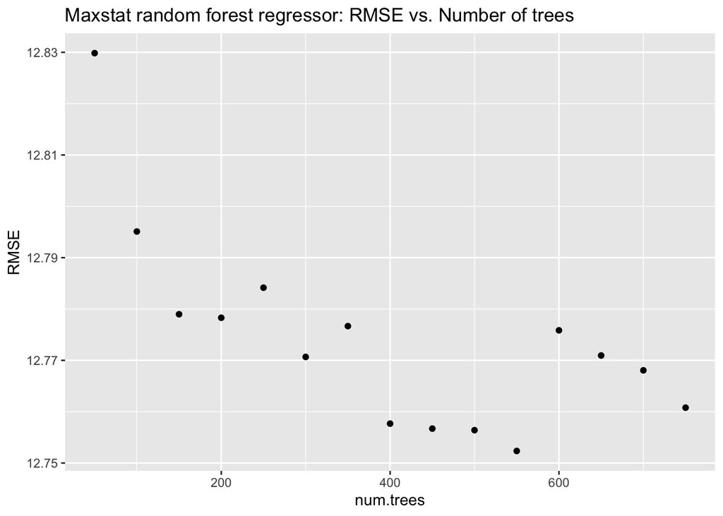

```r
rf_chosen_hyperparameters <- expand.grid(
  mtry = 1,
  min.node.size = 15,
  splitrule = "maxstat"
)
num_trees_tuning_values <- seq(from = 50, by = 50, to = 750)

rf_results_by_n_trees <- map(
  num_trees_tuning_values, get_rf_cv_results, grid = rf_chosen_hyperparameters
) %>%
  bind_rows()

ggplot(rf_results_by_n_trees) +
  geom_point(mapping = aes(x = num.trees, y = RMSE)) +
  ggtitle("Maxstat random forest regressor: RMSE vs. Number of trees")
```

We’re dealing with very small variations in RMSE, but you could probably make an argument that the RMSE is mostly better when num.trees >= 150, so I’ll set num.trees equal to 150.

With all of the hyperparameters set, I can now train the final random forest regressor.

```r
rf_maxstat_model <- train(
  x = train_features,
  y = train_responses,
  method = "ranger",
  trControl = trainControl(method = "none"),
  tuneGrid = rf_chosen_hyperparameters,
  num.trees = 150
)
```

I’ll also train a random forest regressor that uses the “variance” splitrule. It wasn’t the optimal choice, but it is the default option, and I’m curious to see how it performs in comparison to our “maxstat” regressor.

I’ll first check what the optimal hyperparameters for that regressor are.

```r
rf_hyperparam_opt_results %>%
  filter(splitrule == "variance") %>%
  slice_min(order_by = RMSE, n = 10) %>%
  kbl(
    align = rep("c", ncol(rf_hyperparam_opt_results)),
    caption = 'Random forest hyperparameter tuning results ("variance" only)',
    digits = 3
  ) %>%
  kable_styling(
    bootstrap_options = c("striped", "hover", "condensed", "responsive")
  )
```

Random forest hyperparameter tuning results (“variance” only)

| num.trees | mtry | min.node.size | splitrule | RMSE |
| --- | --- | --- | --- | --- |
| 100 | 1 | 15 | variance | 13.346 |
| 100 | 1 | 13 | variance | 13.494 |
| 100 | 1 | 11 | variance | 13.507 |
| 100 | 1 | 9 | variance | 13.507 |
| 100 | 1 | 5 | variance | 13.648 |
| 100 | 1 | 7 | variance | 13.655 |
| 100 | 2 | 15 | variance | 13.718 |
| 100 | 2 | 13 | variance | 13.799 |
| 100 | 1 | 3 | variance | 13.862 |
| 100 | 2 | 11 | variance | 13.965 |

It still appears that mtry = 1 is optimal. This time though there’s a steady decrease in the RMSE as min.node.size is increased, so I’ll try the largest value: min.node.size = 15.

With those hyperparameters set, I’ll now tune the number of trees grown for the model.

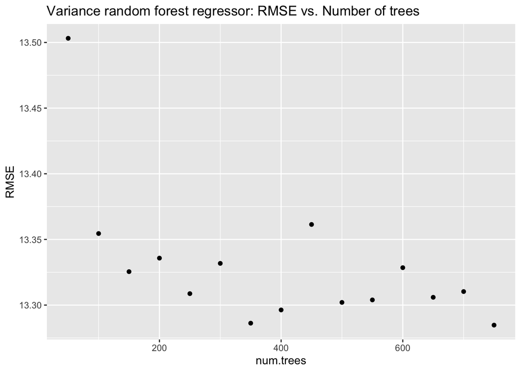

```r
variance_rf_chosen_hyperparameters <- expand.grid(
  mtry = 1,
  min.node.size = 15,
  splitrule = "variance"
)

variance_rf_results_by_n_trees <- map(
  num_trees_tuning_values, get_rf_cv_results,
  grid = variance_rf_chosen_hyperparameters
) %>%
  bind_rows()

ggplot(variance_rf_results_by_n_trees) +
  geom_point(mapping = aes(x = num.trees, y = RMSE)) +
  ggtitle("Variance random forest regressor: RMSE vs. Number of trees")
```

Again, there’s no real clear pattern of decrease in RMSE as num.trees increases, but it does look like avoiding num.trees = 50 might be wise. Let’s grow 100 trees.

I can now train the final “variance” random forest regressor.

```r
rf_variance_model <- train(
  x = train_features,
  y = train_responses,
  method = "ranger",
  trControl = trainControl(method = "none"),
  tuneGrid = variance_rf_chosen_hyperparameters,
  num.trees = 100
)
```

While there are reasons to expect the relationship between relative team quality and final scoring margin to be non-linear, it seems reasonably likely that the dataset is not going to be large enough to train models that can accurately capture that non-linearity. There’s a risk that non-linear models will instead overfit to noise, and so this provides a rationale to also try training linear models, as they should be more robust to this type of overfitting.

I’ll start by training a group of basic linear regression models:

- one that uses only the difference in DAVE between teams
- one that uses only the final point spread of the game
- one that uses both of these features

```r
training_set <- game_data[train_indices, ]

dave_only_lm <- lm(Outcome ~ `DAVE Difference`, training_set)
line_only_lm <- lm(Outcome ~ `Final Betting Line`, training_set)
dave_and_line_lm <- lm(
  Outcome ~ `Final Betting Line` + `DAVE Difference`, training_set
)
```

I’ll also train a couple of support vector regression (SVR) models. The caret package includes both the svmLinear2 and svmLinear3 models, so I’ll try both, starting with svmLinear2.

There are two hyperparameters to tune here: - cost: the size of the penalty associated with incorrect estimations of outcomes within the training dataset. In other words, a larger cost will cause the model to fit more tightly to the training dataset, while a smaller cost will have the opposite effect. - svr_eps: defines a tolerance margin - errors of less than this amount will not contribute to the total loss

```r
tune_svm2_with_epsilon <- function(epsilon) {
  svm2_cv <- train(
    x = train_features,
    y = train_responses,
    method = "svmLinear2",
    trControl = trainControl(method = "repeatedcv", number = 10, repeats = 5),
    tuneGrid = expand.grid(cost = seq(from = 0.25, by = 0.25, to = 1.5)),
    svr_eps = epsilon
  )

  svm2_cv_results <- svm2_cv$results %>%
    mutate(svr_eps = epsilon) %>%
    select(cost, svr_eps, RMSE)

  return(svm2_cv_results)
}

svr_eps_grid <- c(0.02, 0.1, 0.5, 1, 2)

svm2_tuning_results <- map(svr_eps_grid, tune_svm2_with_epsilon) %>%
  bind_rows()

svm2_tuning_results %>%
  slice_min(order_by = RMSE, n = 10) %>%
  kbl(
    align = rep("c", ncol(svm2_tuning_results)),
    caption = 'svm2Linear hyperparameter tuning results',
    digits = 3
  ) %>%
  kable_styling(
    bootstrap_options = c("striped", "hover", "condensed", "responsive")
  )
```

svm2Linear hyperparameter tuning results

| cost | svr_eps | RMSE |
| --- | --- | --- |
| 0.25 | 2.0 | 12.617 |
| 0.50 | 2.0 | 12.617 |
| 0.75 | 2.0 | 12.618 |
| 1.00 | 2.0 | 12.618 |
| 1.25 | 2.0 | 12.618 |
| 1.50 | 2.0 | 12.618 |
| 0.25 | 0.1 | 12.621 |
| 0.50 | 0.1 | 12.621 |
| 1.50 | 0.1 | 12.622 |
| 0.75 | 0.1 | 12.622 |

We’re really splitting hairs here, but it looks like the cross-validation RMSE is minimized when cost = 0.25 and svr_eps = 2, so I’ll use those values to train the final svmLinear2 model.

```r
svm2_model <- train(
  x = train_features,
  y = train_responses,
  method = "svmLinear2",
  trControl = trainControl(method = "none"),
  tuneGrid = expand.grid(cost = 0.25),
  svr_eps = 2
)
```

Now I can move on to an svmLinear3 model, which will be the last model that I train.

In addition to the cost and svr_eps hyperparameters, this model has one other:

- Loss: either L1 (sum of absolute residuals) or L2 (sum of squared residuals). Since we’re seeking to minimize RMSE in all of our other models, let’s just choose to always use an L2 loss function here, rather than tuning the hyperparameter.

```r
tune_svm3_with_epsilon <- function(epsilon) {
  svm3_cv <- train(
    x = train_features,
    y = train_responses,
    method = "svmLinear3",
    trControl = trainControl(method = "repeatedcv", number = 10, repeats = 5),
    tuneGrid = expand.grid(
      cost = seq(from = 0.25, by = 0.25, to = 1.5), Loss = "L2"
    ),
    svr_eps = epsilon
  )

  svm3_cv_results <- svm3_cv$results %>%
    mutate(svr_eps = epsilon) %>%
    select(cost, svr_eps, RMSE)

  return(svm3_cv_results)
}

svr_eps_grid <- c(0.02, 0.1, 0.5, 1, 2)

svm3_tuning_results <- map(svr_eps_grid, tune_svm3_with_epsilon) %>%
  bind_rows()

svm3_tuning_results %>%
  slice_min(order_by = RMSE, n = 10) %>%
  kbl(
    align = rep("c", ncol(svm3_tuning_results)),
    caption = 'svm3Linear hyperparameter tuning results',
    digits = 3
  ) %>%
  kable_styling(
    bootstrap_options = c("striped", "hover", "condensed", "responsive")
  )
```

svm3Linear hyperparameter tuning results

| cost | svr_eps | RMSE |
| --- | --- | --- |
| 0.75 | 2.00 | 12.625 |
| 1.50 | 0.02 | 12.626 |
| 0.50 | 0.02 | 12.627 |
| 1.00 | 0.02 | 12.627 |
| 0.25 | 0.50 | 12.628 |
| 0.25 | 2.00 | 12.628 |
| 1.00 | 2.00 | 12.629 |
| 0.50 | 1.00 | 12.629 |
| 1.25 | 2.00 | 12.630 |
| 0.50 | 0.50 | 12.630 |

The lowest RMSE comes about when cost = 0.75 and svr_eps = 2, so I’ll use those values to train the final version of this model.

```r
svmlinear3_chosen_hyperparameters <- expand.grid(cost = 0.75, Loss = "L2")

svm3_model <- train(
  x = train_features,
  y = train_responses,
  method = "svmLinear3",
  trControl = trainControl(method = "none"),
  tuneGrid = svmlinear3_chosen_hyperparameters,
  svr_eps = 2
)
```

I now have a set of seven different models - two random forest regression models, three linear regression models, and two support vector regressors.

```r
models <- list(
  "DAVE LM" = dave_only_lm, "Spread LM" = line_only_lm,
  "DAVE + Spread LM" = dave_and_line_lm, "Maxstat RF" = rf_maxstat_model,
  "Variance RF" = rf_variance_model, "SVM2" = svm2_model, "SVM3" = svm3_model
)
```

Before I test them on our test dataset, I’ll use each model to make predictions on some fake data that spans a wide range of point spreads and DAVE differences.

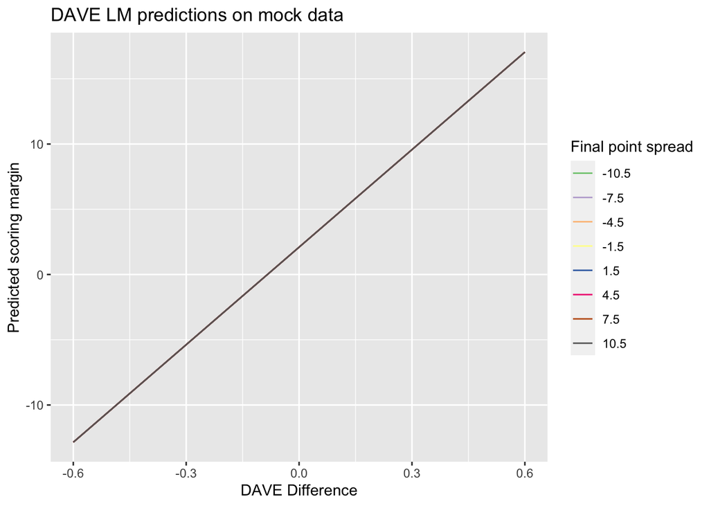

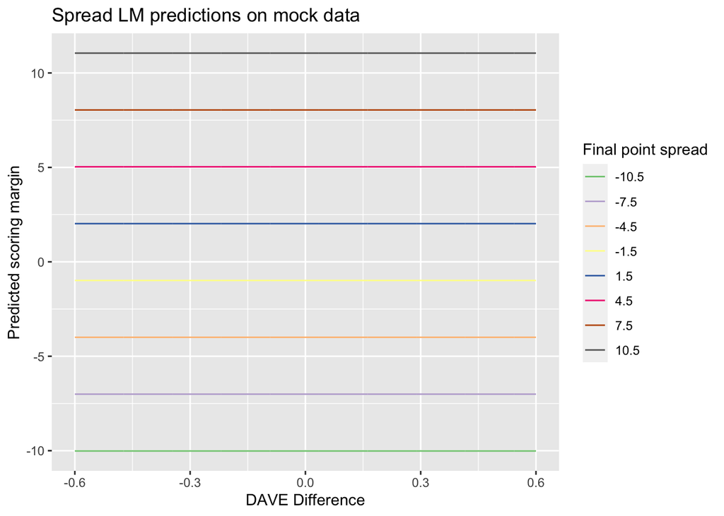

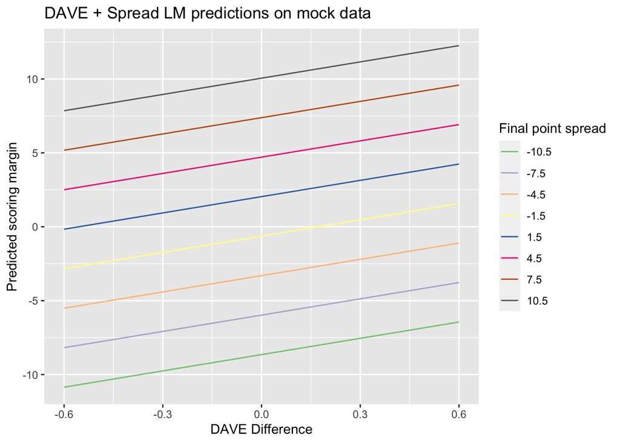

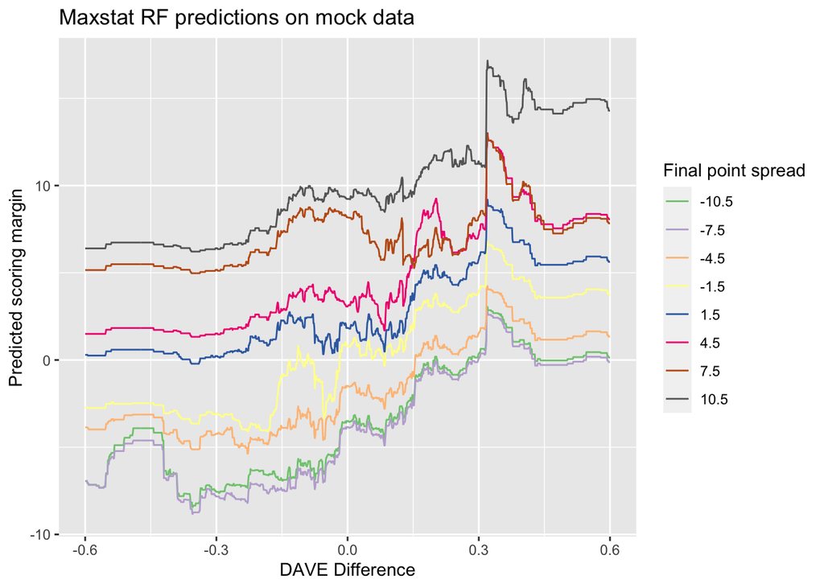

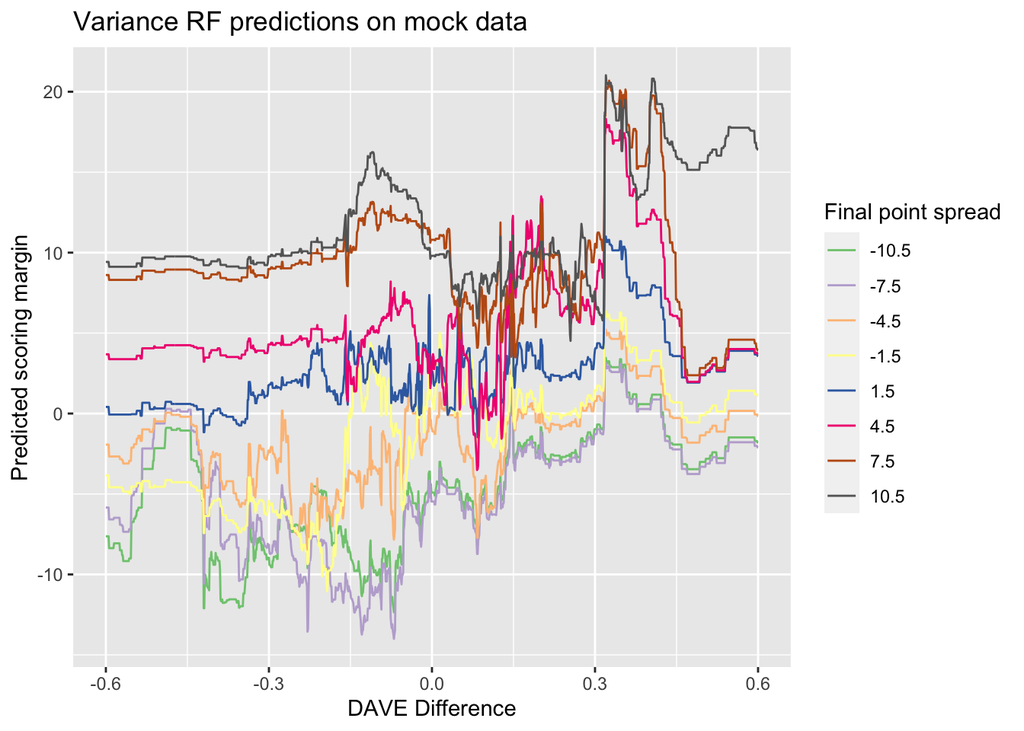

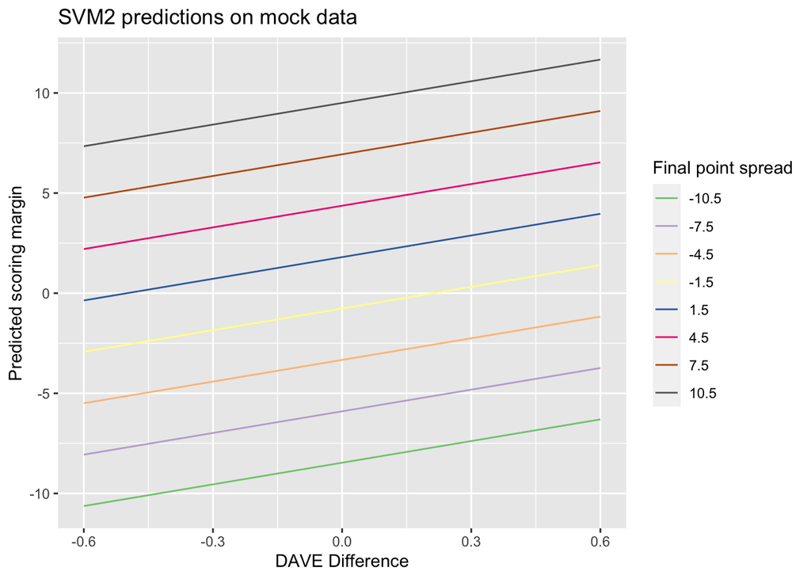

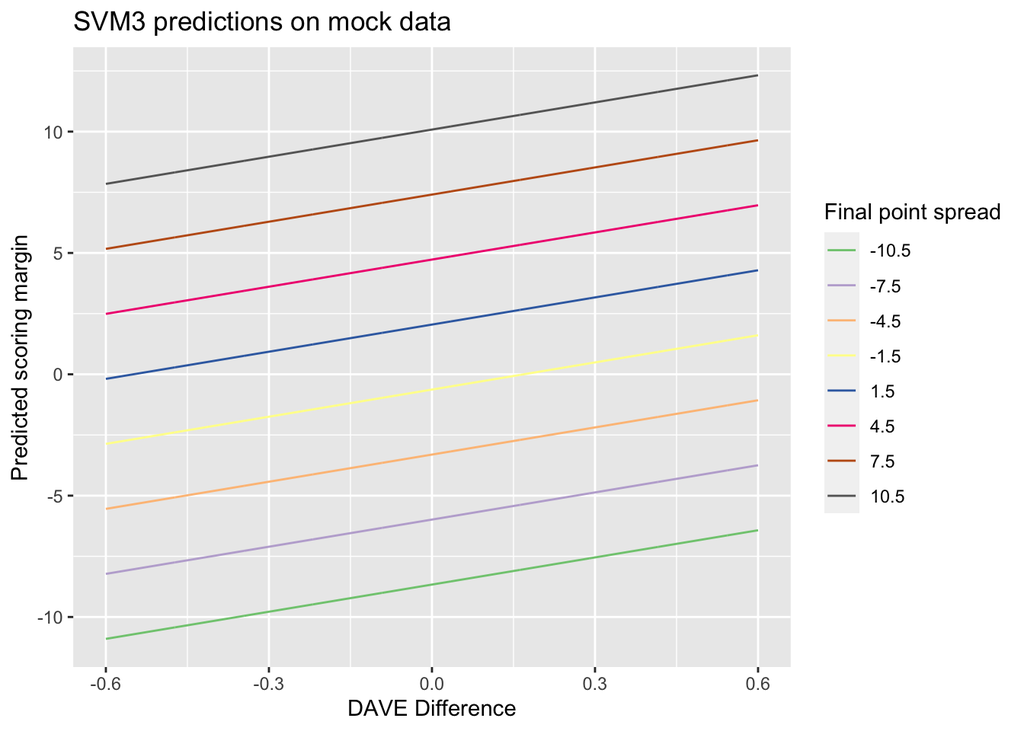

```r
mock_spreads <- seq(from = -10.5, by = 3, to = 10.5)
mock_DAVE_differences <- seq(from = -0.6, by = 0.001, to = 0.6)
mock_data <- crossing(mock_spreads, mock_DAVE_differences) %>%
  rename(
    `Final Betting Line` = mock_spreads,
    `DAVE Difference` = mock_DAVE_differences
  )

assess_model_on_mock_data <- function(model, model_name) {
  mock_predictions <- mock_data %>%
    mutate(prediction = predict(model, newdata = mock_data))

  assessment <- ggplot(
    mock_predictions,
    mapping = aes(
      x = `DAVE Difference`,
      y = prediction,
      color = as.factor(`Final Betting Line`)
    )
  ) +
    geom_line() +
    scale_color_brewer(type = "qual") +
    labs(
      title = glue("{model_name} predictions on mock data"),
      y = "Predicted scoring margin",
      color = "Final point spread"
    )

  print(assessment)
}

walk2(models, names(models), assess_model_on_mock_data)
```

For the most part these models are doing what I’d expect them to, but there are a couple of things that are worth noting.

As I also saw in 2023 and 2024’s model training, the random forest models really appear to be overfit. Their predicted scoring margin isn’t even close to being a monotonic function of the DAVE difference (or of the final point spread), and there are areas where small changes in the DAVE difference cause the predicted scoring margin to spike. That being said, the maxstat random forest model certainly appears to be *less* of an overfit mess than the variance random forest model. I guess our tuning worked!

Next, I’ll take a look at how each of these models performs on the **training** dataset. This will give me some further insight into whether any of the models are likely to be overfit, and whether any of them have picked up tendencies that are likely to diminish their predictive power (e.g. having a strong bias for or against home teams or favourites).

```r
report_model_stats_on_dataset <- function(model, name, dataset) {
  dataset <- mutate(
    dataset,
    prediction = predict(model, dataset),
    line_movement = `Final Betting Line` - `OFP Line`,
    picked_home = prediction > `OFP Line`,
    picked_favourite = (picked_home == (`OFP Line` > 0)),
    picked_line_movement = if_else(
      line_movement != 0, picked_home == (line_movement > 0), NA
    ),
    picked_correctly = (picked_home == (Outcome > `OFP Line`))
  )

  overall_win_rate <- mean(dataset$picked_correctly)
  home_pick_rate <- mean(dataset$picked_home)
  home_pick_win_rate <- dataset %>%
    filter(picked_home) %>%
    pull(picked_correctly) %>%
    mean()
  favourite_pick_rate <- mean(dataset$picked_favourite)
  favourite_pick_win_rate <- dataset %>%
    filter(picked_favourite) %>%
    pull(picked_correctly) %>%
    mean()
  movement_pick_rate <- mean(dataset$picked_line_movement, na.rm = TRUE)
  movement_pick_win_rate <- dataset %>%
    filter(picked_line_movement) %>%
    pull(picked_correctly) %>%
    mean()
  no_movement_win_rate <- dataset %>%
    filter(line_movement == 0) %>%
    pull(picked_correctly) %>%
    mean()

  return(
    tibble(
      name, overall_win_rate, home_pick_rate, home_pick_win_rate,
      favourite_pick_rate, favourite_pick_win_rate, movement_pick_rate,
      movement_pick_win_rate, no_movement_win_rate
    )
  )
}

model_performance_on_training_set <- map2(
  models, names(models), report_model_stats_on_dataset, dataset = training_set
) %>%
  bind_rows()

model_performance_on_training_set %>%
  kbl(
    align = rep("c", ncol(model_performance_on_training_set)),
    caption = "Performance of all models on the training set",
    digits = 3,
    col.names = c(
      "Model", "Win rate", "Home pick rate", "Win rate (picking home teams)",
      "Favourite pick rate", "Win rate (picking favourites)",
      "Line movement pick rate", "Win rate (picking with line movement)",
      "Win rate (no line movement)")
  ) %>%
  kable_styling(
    bootstrap_options = c("striped", "hover", "condensed", "responsive")
  )
```

Performance of all models on the training set

| Model | Win rate | Home pick rate | Win rate (picking home teams) | Favourite pick rate | Win rate (picking favourites) | Line movement pick rate | Win rate (picking with line movement) | Win rate (no line movement) |
| --- | --- | --- | --- | --- | --- | --- | --- | --- |
| DAVE LM | 0.516 | 0.571 | 0.526 | 0.310 | 0.535 | 0.555 | 0.564 | 0.448 |
| Spread LM | 0.536 | 0.749 | 0.533 | 0.550 | 0.538 | 0.817 | 0.554 | 0.481 |
| DAVE + Spread LM | 0.520 | 0.703 | 0.524 | 0.529 | 0.524 | 0.856 | 0.543 | 0.453 |
| Maxstat RF | 0.643 | 0.515 | 0.652 | 0.448 | 0.665 | 0.706 | 0.636 | 0.597 |
| Variance RF | 0.744 | 0.525 | 0.745 | 0.483 | 0.758 | 0.618 | 0.741 | 0.674 |
| SVM2 | 0.533 | 0.620 | 0.538 | 0.457 | 0.542 | 0.912 | 0.548 | 0.464 |
| SVM3 | 0.522 | 0.701 | 0.526 | 0.531 | 0.526 | 0.856 | 0.544 | 0.453 |

This largely confirms what I saw before. The two RF models have unrealistically high win rates on the training set, with the variance RF being worse, which suggests overfitting. The other models all achieve more reasonable win rates and have a stronger bias towards picking teams with favourable line movement (save for the DAVE-only model), which is encouraging.

My 2023 models ended up being considerably more successful than the 2024 models, with cover rates of 54-55% vs. 49-50%, so I’ll use the training set performance of the 2023 models as a point of comparison. The 2023 LM and SVM models picked a substantially lower proportion of home teams (36-46%) and favourites (23-30%) in their training set than these 2025 models (57-75% and 31-55%, respectively) did. This makes some sense, given that the actual 2023 and 2024 results, present only in the 2025 models’ training set, both had home cover rates > 50% and averaged a favourite cover rate of > 55%.

The line movement pick rates are comparable between the 2025 and 2023 models, which is good, but for some reason the training set cover rate when there was no line movement is much lower in the 2025 models (45-48% vs. 50-58%).

Based on these stats and the mock data predictions, I’m expecting either the DAVE + Spread linear model or one of the SVM models to have the best performance on the test data. Time to find out!

```r
test_set <- game_data[-train_indices, ]

model_performance_on_test_set <- map2(
  models, names(models), report_model_stats_on_dataset, dataset = test_set
) %>%
  bind_rows()

model_performance_on_test_set %>%
  kbl(
    align = rep("c", ncol(model_performance_on_test_set)),
    caption = "Performance of all models on the test set",
    digits = 3,
    col.names = c(
      "Model", "Win rate", "Home pick rate", "Win rate (picking home teams)",
      "Favourite pick rate", "Win rate (picking favourites)",
      "Line movement pick rate", "Win rate (picking with line movement)",
      "Win rate (no line movement)")
  ) %>%
  kable_styling(
    bootstrap_options = c("striped", "hover", "condensed", "responsive")
  )
```

Performance of all models on the test set

| Model | Win rate | Home pick rate | Win rate (picking home teams) | Favourite pick rate | Win rate (picking favourites) | Line movement pick rate | Win rate (picking with line movement) | Win rate (no line movement) |
| --- | --- | --- | --- | --- | --- | --- | --- | --- |
| DAVE LM | 0.504 | 0.595 | 0.452 | 0.326 | 0.488 | 0.493 | 0.533 | 0.549 |
| Spread LM | 0.527 | 0.723 | 0.476 | 0.568 | 0.513 | 0.854 | 0.555 | 0.412 |
| DAVE + Spread LM | 0.515 | 0.735 | 0.469 | 0.534 | 0.504 | 0.836 | 0.545 | 0.431 |
| Maxstat RF | 0.549 | 0.564 | 0.490 | 0.455 | 0.542 | 0.695 | 0.554 | 0.608 |
| Variance RF | 0.545 | 0.515 | 0.485 | 0.466 | 0.537 | 0.587 | 0.576 | 0.529 |
| SVM2 | 0.527 | 0.633 | 0.473 | 0.447 | 0.517 | 0.897 | 0.534 | 0.549 |
| SVM3 | 0.519 | 0.739 | 0.472 | 0.538 | 0.507 | 0.831 | 0.548 | 0.431 |

My first takeaway here is that the RF models are performing surprisingly well. Still, I don’t trust models that are that clearly overfit.

The model that I trust most out of these is probably the SVM2 model. It has a relatively restrained pick rate for home teams (63%) and for favourites (45%), while aggressively picking with line movement (90%). It also performs decently when there’s no line movement.

Let’s take a closer look at what’s happening to the linear models:

```r
models[c("DAVE LM", "DAVE + Spread LM")]
```

```
## $`DAVE LM`
##
## Call:
## lm(formula = Outcome ~ `DAVE Difference`, data = training_set)
##
## Coefficients:
##       (Intercept)  `DAVE Difference`
##             2.095             24.917
##
##
## $`DAVE + Spread LM`
##
## Call:
## lm(formula = Outcome ~ `Final Betting Line` + `DAVE Difference`,
##     data = training_set)
##
## Coefficients:
##          (Intercept)  `Final Betting Line`     `DAVE Difference`
##               0.7007                0.8906                3.6720
```

Incidentally, this suggests that home-field advantage comes out to around 2.1 points, which is a plausible value.

Here are some of the 2023 and 2024 linear models for comparison:

```r
models_2024 <- here("2024/trained-models.rds") %>% read_rds()
names(models_2024) <- c(
  "DAVE LM 2024", "DAVE + Spread LM 2024", "SVM3 2024", "DAVE + Spread LM 2023",
  "SVM3 2023"
)
models_2024["DAVE + Spread LM 2024"]
```

```
## $`DAVE + Spread LM 2024`
##
## Call:
## lm(formula = Outcome ~ `Final Betting Line` + `DAVE Difference`,
##     data = training_set)
##
## Coefficients:
##          (Intercept)  `Final Betting Line`     `DAVE Difference`
##               0.6769                0.9253                5.1241
```

```r
models_2024["DAVE + Spread LM 2023"]
```

```
## $`DAVE + Spread LM 2023`
##
## Call:
## lm(formula = Outcome ~ `Final Betting Line` + `DAVE Difference`,
##     data = training_set)
##
## Coefficients:
##          (Intercept)  `Final Betting Line`     `DAVE Difference`
##              0.06606               0.76959               5.41931
```

Relative to the previous models, this year’s puts less weight on the DAVE difference, while having a similar home-field advantage and weight on the final betting line as the 2024 model. I still think I prefer the 2023 model - there shouldn’t be any excess home-field advantage that isn’t accounted for in the betting line!

Given how strangely this year’s models have turned out, I’m still going to track some of the 2023 models as well this year, and take them into account when making picks.

```r
chosen_models <- c(
  models[c("DAVE + Spread LM", "SVM2", "SVM3")],
  models_2024[c("DAVE + Spread LM 2023", "SVM3 2023")])
write_rds(chosen_models, here("2025", "trained-models.rds"))
```